# Evaluación de impacto - Taller IV (Parte II)

Autor: Juan Sebastián Cañas

Universidad Nacional de Colombia

Noviembre del 2020

Notebook con el código necesario para obtener los resultados del [taller IV](https://github.com/fbogliacino/Evaluacion-de-Impacto-/blob/master/Talleres/Taller%20IV.docx) de EVIMP-2020 sobre el artículo [Punishment and Deterrance: Evidence from Drunk Driving](https://www.aeaweb.org/articles?id=10.1257/aer.20130189) de Benjamin Hansen (2015).

Seguimos las instrucciones de la parte II del taller:

Una vez tenga los datos en el programa, use la variable “low_score” (dividida por mil) como indicación del BAC, ejecute los siguientes pasos (note que los resultados no van a coincidir exactamente, no se preocupe por eso):

```r
library(tidyverse)
library(rdrobust)
library(rddensity)
library(readstata13)
library(broom)
library(modelsummary)
library(rdlocrand)
```

```r
dui <- read.dta13("/Users/jscs/Downloads/hansen_dwi.dta")
dui$BAC <- dui$low_score/1000
print('Dimensiones de la base de datos completa')
```

```
[1] "Dimensiones de la base de datos completa"
```

```r
print(dim(dui))
```

```
[1] 214558     13
```

```r
dui_filtered <- filter(dui, BAC > 0.03 & BAC < 0.2)
print('Dimensiones de la base de datos filtrada para valores de BAC entre 0.03 y 0.2')
```

```
[1] "Dimensiones de la base de datos filtrada para valores de BAC entre 0.03 y 0.2"
```

```r
print(dim(dui_filtered))
```

```
[1] 183256     13
```

```r
head(dui_filtered)
```

|  | Date | Alcohol1 | Alcohol2 | low_score | male | white | recidivism | acc | aged | year | bac1 | bac2 | BAC |
| --- | --- | --- | --- | --- | --- | --- | --- | --- | --- | --- | --- | --- | --- |
| 1 | 2001-09-30 | 151 | 150 | 150 | 1 | 1 | 0 | 0 | 56 | 2001 | 0.151 | 0.150 | 0.150 |
| 2 | 2005-09-23 | 156 | 153 | 153 | 1 | 0 | 0 | 0 | 32 | 2005 | 0.156 | 0.153 | 0.153 |
| 3 | 2004-04-25 | 164 | 165 | 164 | 1 | 1 | 0 | 0 | 28 | 2004 | 0.164 | 0.165 | 0.164 |
| 4 | 2005-12-21 | 155 | 155 | 155 | 1 | 1 | 0 | 1 | 36 | 2005 | 0.155 | 0.155 | 0.155 |
| 5 | 2002-03-19 | 165 | 163 | 163 | 1 | 1 | 0 | 0 | 52 | 2002 | 0.165 | 0.163 | 0.163 |
| 6 | 2004-09-02 | 154 | 161 | 154 | 0 | 1 | 0 | 0 | 55 | 2004 | 0.154 | 0.161 | 0.154 |

1. Reproduzca la Fig 1, con un histograma con clases de frecuencia de amplitud 0.0001 y dos líneas verticales en correspondencia de DUI y DUI agravado

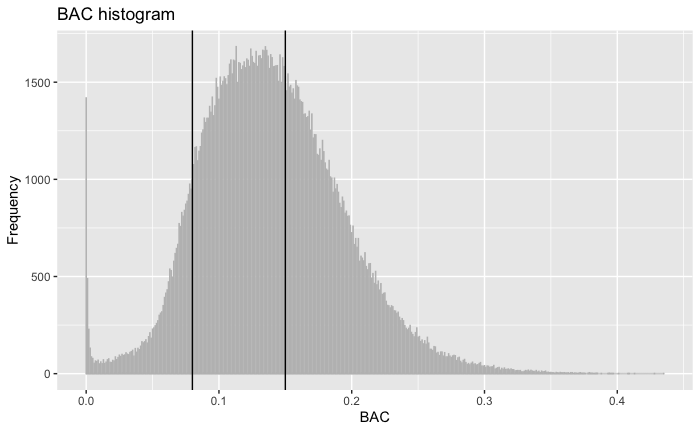

```r
ggplot(dui, aes(x = BAC, )) +
  geom_histogram(binwidth = 0.0001, color = "gray",) +
  geom_vline(xintercept = 0.08) + geom_vline(xintercept = 0.15) +
  labs(title = "BAC histogram",
         x = "BAC",
         y = "Frequency")
```

2. Conduzca el test de McCrary al nivel del DUI, ploteándolo gráficamente y reportando el p-value

```r
test_density <- rddensity(dui$BAC, c = 0.08)
summary(test_density)
```

```
Manipulation testing using local polynomial density estimation.

Number of obs =       214558
Model =               unrestricted
Kernel =              triangular
BW method =           estimated
VCE method =          jackknife

c = 0.08              Left of c           Right of c
Number of obs         23809               190749
Eff. Number of obs    15060               31301
Order est. (p)        2                   2
Order bias (q)        3                   3
BW est. (h)           0.023               0.023

Method                T                   P > |T|
Robust                1.4614              0.1439
```

```
There are repeated observations. Point estimates and standard errors have been adjusted. Use option massPoints=FALSE to suppress this feature.
```

```
P-values of binomial tests (H0: p=0.5).

Window Length / 2          <c     >=c    P>|T|
0.000                       0     998    0.0000
```

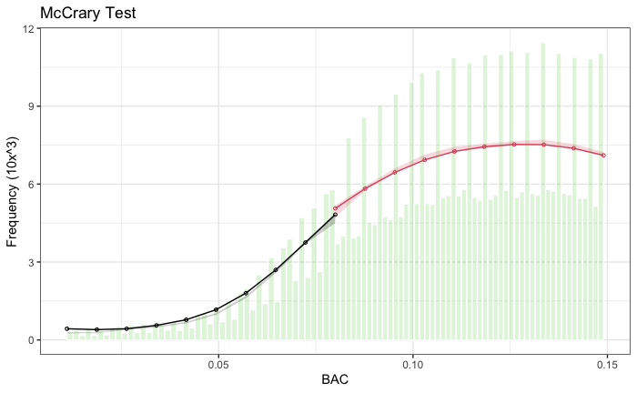

```r
plot_density_test <- rdplotdensity(rdd = test_density, dui$BAC, type = "both",
                                   xlabel = 'BAC', ylabel = 'Frequency (10x^3)',title = 'McCrary Test')
```

3. Reproduzca parcialmente la Tabla 2 columnas (1)-(4) , Panel (A), usando el mismo modelo estimado en el artículo;

```r
rdrobust(y = dui_filtered$white, x = dui_filtered$BAC, c=0.08, p=2, h=0.05, kernel = 'uniform' ) %>%
  summary()
```

```
[1] "Mass points detected in the running variable."
Call: rdrobust

Number of Obs.               183256
BW type                      Manual
Kernel                      Uniform
VCE method                       NN

Number of Obs.               19572      163684
Eff. Number of Obs.          19572       74220
Order est. (p)                   2           2
Order bias  (q)                  3           3
BW est. (h)                  0.050       0.050
BW bias (b)                  0.050       0.050
rho (h/b)                    1.000       1.000
Unique Obs.                     49         120

=============================================================================
        Method     Coef. Std. Err.         z     P>|z|      [ 95% C.I. ]
=============================================================================
  Conventional    -0.006     0.007    -0.816     0.415    [-0.020 , 0.008]
        Robust         -         -    -1.150     0.250    [-0.030 , 0.008]
=============================================================================
```

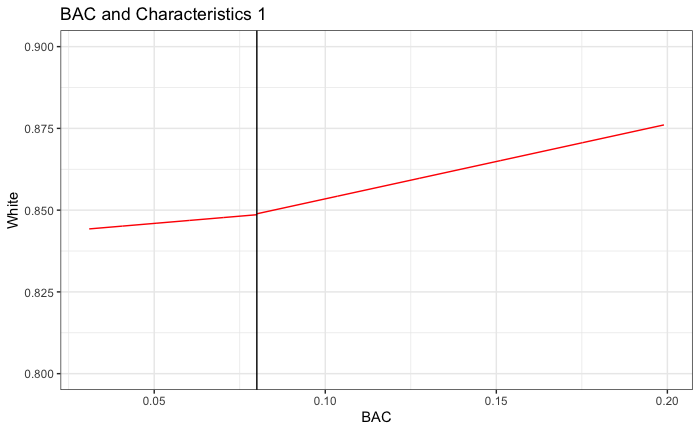

```r
out <- rdplot(y = dui_filtered$white, x = dui_filtered$BAC, c=0.08, support=c(0.05, 0.13), p=1 ,nbins = 0.002, kernel = 'uniform',
      #  x . lim = c ( -100 , + 100) , y . lim = c (0 , 25)
      y.lim = c(0.8,0.9),
         x.label ='BAC', y.label = 'White' ,title='BAC and Characteristics 1')
```

```r
summary(out)
```

```
Call: rdplot

Number of Obs.               183256
Kernel                      Uniform

Number of Obs.               19572         163684
Eff. Number of Obs.          19572         163684
Order poly. fit (p)              1              1
BW poly. fit (h)             0.049          0.119
Number of bins scale             1              1

Bins Selected                    0              0
Average Bin Length              NA             NA
Median Bin Length               NA             NA

IMSE-optimal bins                5              6
Mimicking Variance bins       1131           1361

Relative to IMSE-optimal:
Implied scale                0.000          0.000
WIMSE variance weight        1.000          1.000
WIMSE bias weight            0.000          0.000
```

```r
rdrobust(y = dui_filtered$male, x = dui_filtered$BAC, c=0.08, p=2, h=0.05, kernel = 'uniform' ) %>%
  summary()
```

```
[1] "Mass points detected in the running variable."
Call: rdrobust

Number of Obs.               183256
BW type                      Manual
Kernel                      Uniform
VCE method                       NN

Number of Obs.               19572      163684
Eff. Number of Obs.          19572       74220
Order est. (p)                   2           2
Order bias  (q)                  3           3
BW est. (h)                  0.050       0.050
BW bias (b)                  0.050       0.050
rho (h/b)                    1.000       1.000
Unique Obs.                     49         120

=============================================================================
        Method     Coef. Std. Err.         z     P>|z|      [ 95% C.I. ]
=============================================================================
  Conventional     0.002     0.008     0.250     0.802    [-0.014 , 0.019]
        Robust         -         -    -0.904     0.366    [-0.032 , 0.012]
=============================================================================
```

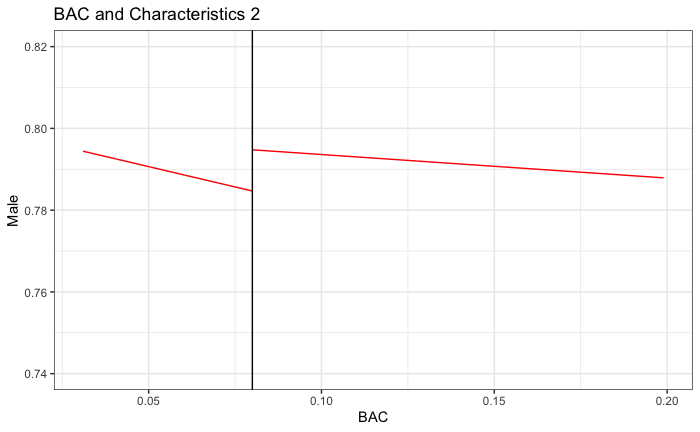

```r
out <- rdplot(y = dui_filtered$male, x = dui_filtered$BAC, c=0.08, support=c(0.05, 0.13), p=1 ,nbins = 0.002, kernel = 'uniform',
      #  x . lim = c ( -100 , + 100) , y .lim = c (0 , 25)
      y.lim = c(0.74,0.82),
         x.label ='BAC', y.label = 'Male' ,title='BAC and Characteristics 2')
```

```r
summary(out)
```

```
Call: rdplot

Number of Obs.               183256
Kernel                      Uniform

Number of Obs.               19572         163684
Eff. Number of Obs.          19572         163684
Order poly. fit (p)              1              1
BW poly. fit (h)             0.049          0.119
Number of bins scale             1              1

Bins Selected                    0              0
Average Bin Length              NA             NA
Median Bin Length               NA             NA

IMSE-optimal bins                4              6
Mimicking Variance bins       1278           1090

Relative to IMSE-optimal:
Implied scale                0.001          0.000
WIMSE variance weight        1.000          1.000
WIMSE bias weight            0.000          0.000
```

```r
rdrobust(y = dui_filtered$aged, x = dui_filtered$BAC, c=0.08, p=2, h=0.05, kernel = 'uniform' ) %>%
  summary()
```

```
[1] "Mass points detected in the running variable."
Call: rdrobust

Number of Obs.               183256
BW type                      Manual
Kernel                      Uniform
VCE method                       NN

Number of Obs.               19572      163684
Eff. Number of Obs.          19572       74220
Order est. (p)                   2           2
Order bias  (q)                  3           3
BW est. (h)                  0.050       0.050
BW bias (b)                  0.050       0.050
rho (h/b)                    1.000       1.000
Unique Obs.                     49         120

=============================================================================
        Method     Coef. Std. Err.         z     P>|z|      [ 95% C.I. ]
=============================================================================
  Conventional    -0.354     0.241    -1.469     0.142    [-0.827 , 0.118]
        Robust         -         -    -1.038     0.299    [-0.962 , 0.296]
=============================================================================
```

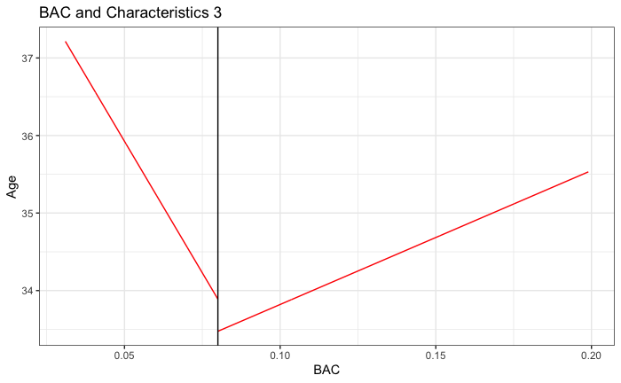

```r
out <- rdplot(y = dui_filtered$aged, x = dui_filtered$BAC, c=0.08, support=c(0.05, 0.13), p=1 ,nbins = 0.002, kernel = 'uniform',
      #  x . lim = c ( -100 , + 100) , y . lim = c (0 , 25)
         x.label ='BAC', y.label = 'Age' ,title='BAC and Characteristics 3')
```

```r
summary(out)
```

```
Call: rdplot

Number of Obs.               183256
Kernel                      Uniform

Number of Obs.               19572         163684
Eff. Number of Obs.          19572         163684
Order poly. fit (p)              1              1
BW poly. fit (h)             0.049          0.119
Number of bins scale             1              1

Bins Selected                    0              0
Average Bin Length              NA             NA
Median Bin Length               NA             NA

IMSE-optimal bins                7             11
Mimicking Variance bins       1216           1449

Relative to IMSE-optimal:
Implied scale                0.000          0.000
WIMSE variance weight        1.000          1.000
WIMSE bias weight            0.000          0.000
```

```r
rdrobust(y = dui_filtered$acc, x = dui_filtered$BAC, c=0.08, p=2, h=0.05, kernel = 'uniform' ) %>%
  summary()
```

```
[1] "Mass points detected in the running variable."
Call: rdrobust

Number of Obs.               183256
BW type                      Manual
Kernel                      Uniform
VCE method                       NN

Number of Obs.               19572      163684
Eff. Number of Obs.          19572       74220
Order est. (p)                   2           2
Order bias  (q)                  3           3
BW est. (h)                  0.050       0.050
BW bias (b)                  0.050       0.050
rho (h/b)                    1.000       1.000
Unique Obs.                     49         120

=============================================================================
        Method     Coef. Std. Err.         z     P>|z|      [ 95% C.I. ]
=============================================================================
  Conventional     0.006     0.006     1.063     0.288    [-0.005 , 0.018]
        Robust         -         -     0.012     0.991    [-0.015 , 0.015]
=============================================================================
```

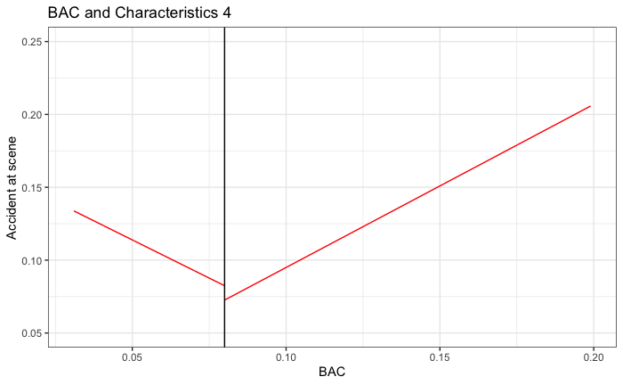

```r
out <- rdplot(y = dui_filtered$acc, x = dui_filtered$BAC, c=0.08, support=c(0.05, 0.13), p=1 ,nbins = 0.002, kernel = 'uniform',
      #  x . lim = c ( -100 , + 100) , y . lim = c (0 , 25)
      y.lim = c(0.05,0.25),
         x.label ='BAC', y.label = 'Accident at scene' ,title='BAC and Characteristics 4')
```

```r
summary(out)
```

```
Call: rdplot

Number of Obs.               183256
Kernel                      Uniform

Number of Obs.               19572         163684
Eff. Number of Obs.          19572         163684
Order poly. fit (p)              1              1
BW poly. fit (h)             0.049          0.119
Number of bins scale             1              1

Bins Selected                    0              0
Average Bin Length              NA             NA
Median Bin Length               NA             NA

IMSE-optimal bins                5             15
Mimicking Variance bins        907            967

Relative to IMSE-optimal:
Implied scale                0.000          0.000
WIMSE variance weight        1.000          1.000
WIMSE bias weight            0.000          0.000
```

4. Reproduzca parcialmente la Tabla 3, columna 1, Panel (A) y (B), usando el mismo modelo y ancho de banda (variable=recidivism);

```r
rdrobust(y = dui_filtered$recidivism, x = dui_filtered$BAC, c = 0.08, h=0.05, p=2,
         covs = cbind(dui_filtered$white, dui_filtered$male, dui_filtered$aged, dui_filtered$acc),
         kernel = "uniform") %>%
  summary()
```

```
[1] "Mass points detected in the running variable."
Call: rdrobust

Number of Obs.               183256
BW type                      Manual
Kernel                      Uniform
VCE method                       NN

Number of Obs.               19572      163684
Eff. Number of Obs.          19572       74220
Order est. (p)                   2           2
Order bias  (q)                  3           3
BW est. (h)                  0.050       0.050
BW bias (b)                  0.050       0.050
rho (h/b)                    1.000       1.000
Unique Obs.                     49         120

=============================================================================
        Method     Coef. Std. Err.         z     P>|z|      [ 95% C.I. ]
=============================================================================
  Conventional    -0.014     0.006    -2.204     0.028    [-0.026 , -0.002]
        Robust         -         -    -2.274     0.023    [-0.036 , -0.003]
=============================================================================
```

```r
rdrobust(y = dui_filtered$recidivism, x = dui_filtered$BAC, c = 0.08, h=0.025, p=2,
         covs = cbind(dui_filtered$white, dui_filtered$male, dui_filtered$aged, dui_filtered$acc),
         kernel = "uniform") %>%
  summary()
```

```
[1] "Mass points detected in the running variable."
Call: rdrobust

Number of Obs.               183256
BW type                      Manual
Kernel                      Uniform
VCE method                       NN

Number of Obs.               19572      163684
Eff. Number of Obs.          15671       34345
Order est. (p)                   2           2
Order bias  (q)                  3           3
BW est. (h)                  0.025       0.025
BW bias (b)                  0.025       0.025
rho (h/b)                    1.000       1.000
Unique Obs.                     49         120

=============================================================================
        Method     Coef. Std. Err.         z     P>|z|      [ 95% C.I. ]
=============================================================================
  Conventional    -0.013     0.009    -1.509     0.131    [-0.030 , 0.004]
        Robust         -         -    -0.991     0.322    [-0.035 , 0.011]
=============================================================================
```

5. Muestre en una gráfica el outcome sobre la running variable, con cutoff a 0.08 y soporte del BAC entre 0.03 y 0.20, con intervalos de confianza, kernel rectangular.

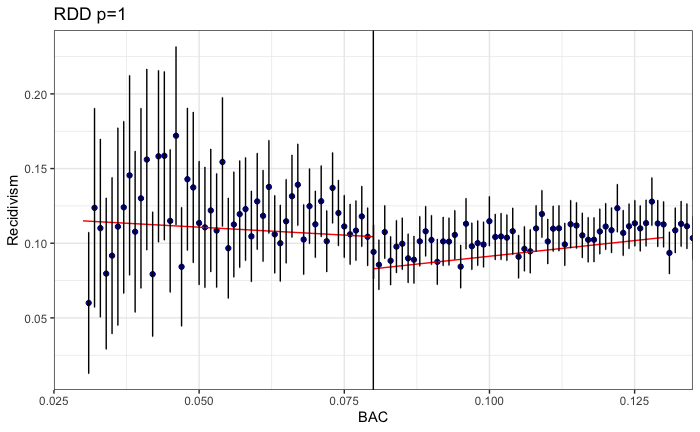

```r
rdplot(y = dui_filtered$recidivism, x = dui_filtered$BAC, c = 0.08, h=0.05, p=1,
         covs = dui_filtered[c("white", "male", "aged", "acc")],
         kernel = "uniform", ci=95, support = c(0.03, 0.2), shade = TRUE,
         x.lim = c(0.03,0.13),
         x.label ='BAC', y.label = 'Recidivism' ,title='RDD p=1')
```

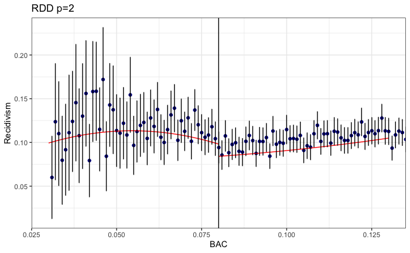

```r
rdplot(y = dui_filtered$recidivism, x = dui_filtered$BAC, c = 0.08, h=0.05, p=2,
         covs = dui_filtered[c("white", "male", "aged", "acc")],
         kernel = "uniform", ci=95, support = c(0.03, 0.2), shade = TRUE,
       x.lim = c(0.03,0.13),
        x.label ='BAC', y.label = 'Recidivism' ,title='RDD p=2', )
```

6. Calcule el pvalor del efecto del DUI usando inferencia randomizada

```r
rdrandinf(Y = dui_filtered$recidivism, R =  dui_filtered$BAC, cutoff = 0.08, p=2,
          kernel = "uniform",statistic = "diffmeans", wl = 0.04 , wr = 0.12 ,
          covariates = dui_filtered[c("white", "male", "aged", "acc")],
          reps=9000, seed=1234)
```

```
Selected window = [0.04;0.12]

Running randomization-based test...
Randomization-based test complete.


Number of obs     =        183256
Order of poly     =             2
Kernel type       =       uniform
Reps              =          9000
Window            =   set by user
H0:          tau  =             0
Randomization     = fixed margins

Cutoff c =    0.080   Left of c  Right of c
      Number of obs       19572      163684
 Eff. number of obs       18574       58037
    Mean of outcome       0.118       0.102
    S.d. of outcome       0.323       0.303
             Window       0.040       0.120

================================================================================
                                  Finite sample            Large sample
                               ------------------  -----------------------------
          Statistic          T        P>|T|        P>|T|    Power vs d =   0.161
================================================================================
     Diff. in means     -0.019        0.000        0.007                   1.000
================================================================================
$sumstats
             [,1]         [,2]
[1,] 1.957200e+04 1.636840e+05
[2,] 1.857400e+04 5.803700e+04
[3,] 1.179068e-01 1.022968e-01
[4,] 3.225064e-01 3.030408e-01
[5,] 4.000000e-02 1.200000e-01

$obs.stat
[1] -0.01873654

$p.value
[1] 0

$asy.pvalue
[1] 0.007088037

$window
[1] 0.04 0.12
```

7. Realice un experimento placebo a 0.04, con ancho de banda .04

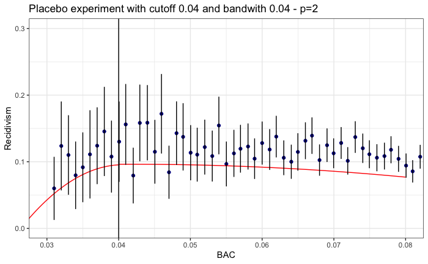

```r
rdplot(y = dui_filtered$recidivism, x = dui_filtered$BAC, c = 0.04, h=0.04, p=2,
         covs = dui_filtered[c("white", "male", "aged", "acc")],
         kernel = "uniform", ci=95, support = c(0.03, 0.2), shade = TRUE,
       x.lim = c(0.03,0.08), y.lim = c(.0,0.3),
        x.label ='BAC', y.label = 'Recidivism' ,title='Placebo experiment with cutoff 0.04 and bandwith 0.04 - p=2')
```

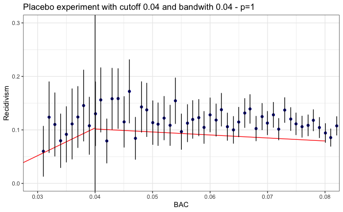

```r
rdplot(y = dui_filtered$recidivism, x = dui_filtered$BAC, c = 0.04, h=0.04, p=1,
         covs = dui_filtered[c("white", "male", "aged", "acc")],
         kernel = "uniform", ci=95, support = c(0.03, 0.2), shade = TRUE,
       x.lim = c(0.03,0.08), y.lim = c(.0,0.3),
        x.label ='BAC', y.label = 'Recidivism' ,title='Placebo experiment with cutoff 0.04 and bandwith 0.04 - p=1')
```